# Ритейл — Оценка эффективности торговых точек

### Визуализация

[Презентация](https://disk.yandex.ru/i/Lh1cs2EvvHSSEw)  
[Дашборд](https://public.tableau.com/views/Retail_16785305253030/Dashboard1?:language=en-US&publish=yes&:display_count=n&:origin=viz_share_link)

### Задача

Оценить эффективность магазинов сети стройматериалов.

- Иследование основных метрик и их сравнение между торговыми точками;
- На основании проведенного анализа составление отчета об эффективности работы магазинов;
- Проверка статистических гипотез с целью определения ключевых метрик, на который торговым точкам следует фокусироваться в дальнейшей работе;
- Формулирование выводов по общей эффективности торговых точек, составление рекомендаций по их дальнейшему развитию.

### План исследования

1. Обзор и описание данных
2. Предобработка данных
   1. Переименование столбцов
   2. Обработка пропущенных значений
   3. Дополнение датасета
   4. Приведение данных к нужным форматам
   5. Обработка дубликатов
      1. Проверка на неявные дубликаты
   6. Анализ и обработка аномальных значений
3. Исследовательский алализ
   1. Выручка торговых точек
      1. Динамика выручки
      2. Сравнение торговых точек
   2. Количество покупок
      1. Динамика изменения количества покупателей
      2. Сравнение торговых точек
   3. Количество уникальных клиентов
      1. Динамика изменения количества покупателей
      2. Сравнение торговых точек
   4. Средний чек
      1. Средняя сумма покупки
      2. Динамика изменения среднего чека
      3. Количество товаров в чеке
      4. Средняя стоимость одного товара в чеке
      5. Сравнение торговых точек
   5. Количество возвратов
      1. Сравнение торговых точек
   6. Количество "пустых" заказов
      1. Сравнение торговых точек
   7. Удержание клиентов
      1. Сравнение торговых точек
   8. Ассортимент товаров
   9. Отличие стоимости товаров в различных магазинах
   10. Выводы
4. Статистический анализ
   1. Проверка гипотезы H0 "Средний чек одинаковый во всех магазинах"
   2. Проверка гипотезы H0 "Клиенты совершают больше покупок в конце года, чем в другое время"
   3. Выводы
5. Итоги исследования

## Обзор и описание данных

```python
import pandas as pd
import numpy as np
import matplotlib.pyplot as plt
import seaborn as sns
from scipy import stats as st
from datetime import datetime
import re

import warnings
warnings.filterwarnings('ignore')
```

```python
sns.set_style("darkgrid")
```

```python
try:
    purchases = pd.read_csv('Datasets/retail_dataset.csv')
except:
    purchases = pd.read_csv('https://code.s3.yandex.net/datasets/retail_dataset.csv')

try:
    products = pd.read_csv('Datasets/product_codes.csv')
except:
    products = pd.read_csv('https://code.s3.yandex.net/datasets/product_codes.csv')
```

**Описание данных:**

Датасет содержит данные о покупках в магазине строительных материалов «Строили, строили и наконец построили».  
Все покупатели могут получить доступ в магазин с использованием персональных карт.  
За 200 рублей в месяц они могут стать участниками программы лояльности.  
В программу включены скидки, специальные предложения, подарки.

Файл retail_dataset.csv:

- `purchaseId` — id чека;
- `item_ID` — id товара;
- `purchasedate` — дата покупки;
- `Quantity` — количество товара;
- `CustomerID` — id покупателя;
- `ShopID` — id магазина;
- `loyalty_program` — участвует ли покупатель в программе лояльности;

```python
purchases.head()
```

|  | purchaseid | item_ID | Quantity | purchasedate | CustomerID | ShopID | loyalty_program |
| --- | --- | --- | --- | --- | --- | --- | --- |
| 0 | 538280 | 21873 | 11 | 2016-12-10 12:50:00 | 18427.0 | Shop 0 | 0.0 |
| 1 | 538862 | 22195 | 0 | 2016-12-14 14:11:00 | 22389.0 | Shop 0 | 1.0 |
| 2 | 538855 | 21239 | 7 | 2016-12-14 13:50:00 | 22182.0 | Shop 0 | 1.0 |
| 3 | 543543 | 22271 | 0 | 2017-02-09 15:33:00 | 23522.0 | Shop 0 | 1.0 |
| 4 | 543812 | 79321 | 0 | 2017-02-13 14:40:00 | 23151.0 | Shop 0 | 1.0 |

```python
purchases.info()
```

```
<class 'pandas.core.frame.DataFrame'>
RangeIndex: 105335 entries, 0 to 105334
Data columns (total 7 columns):
 #   Column           Non-Null Count   Dtype
---  ------           --------------   -----
 0   purchaseid       105335 non-null  object
 1   item_ID          105335 non-null  object
 2   Quantity         105335 non-null  int64
 3   purchasedate     105335 non-null  object
 4   CustomerID       69125 non-null   float64
 5   ShopID           105335 non-null  object
 6   loyalty_program  105335 non-null  float64
dtypes: float64(2), int64(1), object(4)
memory usage: 5.6+ MB
```

Файл product_codes.csv:

- `productID` — id товара;
- `price_per_one` — стоимость одной единицы товара;

```python
products.head()
```

|  | productID | price_per_one |
| --- | --- | --- |
| 0 | 85123A | 2.55 |
| 1 | 71053 | 3.39 |
| 2 | 84406B | 2.75 |
| 3 | 84029G | 3.39 |
| 4 | 84029E | 3.39 |

```python
products.info()
```

```
<class 'pandas.core.frame.DataFrame'>
RangeIndex: 9969 entries, 0 to 9968
Data columns (total 2 columns):
 #   Column         Non-Null Count  Dtype
---  ------         --------------  -----
 0   productID      9969 non-null   object
 1   price_per_one  9969 non-null   float64
dtypes: float64(1), object(1)
memory usage: 155.9+ KB
```

Из общего обзора полученных данных видно, что часть данные содержат пропуски. Также требуется переимование столбцов, проверка на наличие дубликатов и аномальных значений. В связи с этим перед началом анализа требуется произвести предобработку.

## Предобработка данных

### Переименование столбцов

Наименования колонок приводятся к стандартному виду

```python
purchases.columns = ['purchase_id',
                     'item_id',
                     'quantity',
                     'purchase_time',
                     'customer_id',
                     'shop_id',
                     'loyalty'
                    ]
```

```python
products.columns = ['item_id',
                     'price'
                   ]
```

### Обработка пропущенных значений

Пропуски в данных содержатся только в поле `customer_id`.  
Это означает, что эти клиенты не использовали персональную карту или не вводили свои данные при покупкее онлайн.  
Поскольку нам неизвестно, какие клиенты совершили данные покупки, допустимо заполнить данные пропуски значением `0`.

```python
purchases['customer_id'] = purchases['customer_id'].fillna(0)
```

### Дополнение датасета

Как известо из описания данных, для анализа представлено 2 датасета:

1. Информация о совершенных покупках
2. Информация о стоимости товаров

Для дальнейшей обработки удобнее работать с единым датафреймом, поэтому проводится их объединение.

Поскольку некоторые товары имеют несколько цен, а также неизвестно, в какое время действовала каждая из них, необходимо аггрегировать данные о стоимости по `id` товара.  
Для работы была выбрана средняя цена, поскольку разброс цен незначительный.

```python
products = products.groupby('item_id').agg('mean')
```

```python
purchases = purchases.merge(products, on='item_id')
```

Также в объединенный датасет добавляется информация о выручке.

```python
purchases['revenue'] = purchases['price'] * purchases['quantity']
```

### Приведение данных к нужным форматам

Некоторые колонки имеют неверный формат данных, необходимо заменить форматы на подходящие для дальнейшего анализа.

```python
purchases['customer_id'] = purchases['customer_id'].astype('int')
purchases['quantity'] = purchases['quantity'].astype('int')
purchases['purchase_time'] = pd.to_datetime(purchases['purchase_time'])
purchases['loyalty'] = purchases['loyalty'].astype('int')
```

```python
purchases['purchase_date'] = pd.to_datetime(purchases['purchase_time']).dt.date
```

### Обработка дубликатов

```python
purchases.duplicated().sum()
```

```
1033
```

Некоторые записи полностью совпадают, в том числе данные о времени покупки с точностью до секунды.  
Вероятно, это вызвано дублированием записей кассовым аппаратом.  
Повторяющиеся записи удаляются (оставляется одна запись)

```python
purchases = purchases.drop_duplicates().reset_index(drop=True)
```

```python
purchases.head()
```

|  | purchase_id | item_id | quantity | purchase_time | customer_id | shop_id | loyalty | price | revenue | purchase_date |
| --- | --- | --- | --- | --- | --- | --- | --- | --- | --- | --- |
| 0 | 538280 | 21873 | 11 | 2016-12-10 12:50:00 | 18427 | Shop 0 | 0 | 1.81 | 19.91 | 2016-12-10 |
| 1 | 541104 | 21873 | 0 | 2017-01-13 14:29:00 | 0 | Shop 0 | 0 | 1.81 | 0.00 | 2017-01-13 |
| 2 | 540418 | 21873 | 1 | 2017-01-07 11:04:00 | 0 | Shop 0 | 0 | 1.81 | 1.81 | 2017-01-07 |
| 3 | 541516 | 21873 | 2 | 2017-01-18 17:34:00 | 0 | Shop 0 | 0 | 1.81 | 3.62 | 2017-01-18 |
| 4 | 541566 | 21873 | 35 | 2017-01-19 11:50:00 | 23401 | Shop 0 | 1 | 1.81 | 63.35 | 2017-01-19 |

#### Проверка на неявные дубликаты

Категориальные данные необходимо проверить на отсутствие различных форм записи одной категории.

```python
np.sort(purchases['shop_id'].unique())
```

```
array(['Shop 0', 'Shop 1', 'Shop 10', 'Shop 11', 'Shop 12', 'Shop 13',
       'Shop 14', 'Shop 15', 'Shop 16', 'Shop 17', 'Shop 18', 'Shop 19',
       'Shop 2', 'Shop 20', 'Shop 21', 'Shop 22', 'Shop 23', 'Shop 24',
       'Shop 25', 'Shop 26', 'Shop 27', 'Shop 28', 'Shop 29', 'Shop 3',
       'Shop 30', 'Shop 4', 'Shop 5', 'Shop 6', 'Shop 7', 'Shop 8',
       'Shop 9'], dtype=object)
```

```python
purchases['loyalty'].unique()
```

```
array([0, 1])
```

Неявных дубликатов не обнаружено.

### Анализ и обработка аномальных значений

Данные проверяются на наличие `выбросов` - аномальных значений, которые могут сильно исказить результаты анализа.

Для этого используется функция фильтрации по `квантилям`.

```python
def quantile_filter (data,col,bottom,top):

    before_filter = len(data.index)

    top_filter = data[col].quantile(top)
    data = data[data[col] <= top_filter].reset_index(drop=True)

    bottom_filter = data[col].quantile(bottom)
    data = data[data[col] >= bottom_filter].reset_index(drop=True)

    after_filter = len(data.index)

    data_loss = (before_filter - after_filter) / before_filter

    print(f'Выбросы по параметру `{col}` удалены, потеряно {data_loss:.1%} данных')

    return data
```

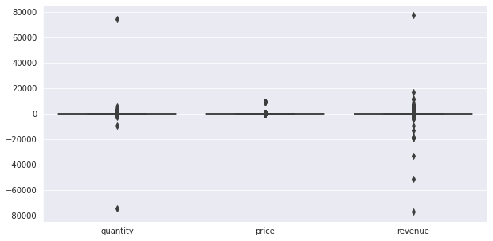

```python
plt.figure(figsize=(10, 5))
sns.boxplot(purchases[['quantity', 'price', 'revenue']]);
```

Как видно из графиков, данные о значениях цены, количества товаров и, соответственно, выручки требуют фильтрации.

```python
purchases['quantity'].quantile([0.001,0.01,0.1,0.9,0.99,0.999])
```

```
0.001    -51.0
0.010     -3.0
0.100      0.0
0.900     19.0
0.990     99.0
0.999    431.0
Name: quantity, dtype: float64
```

```python
purchases['price'].quantile([0.001,0.01,0.1,0.9,0.99,0.999])
```

```
0.001      0.190000
0.010      0.380000
0.100      1.060000
0.900      9.020000
0.990     21.642500
0.999    278.734425
Name: price, dtype: float64
```

```python
purchases['revenue'].quantile([0.001,0.01,0.1,0.9,0.99,0.999])
```

```
0.001    -335.897940
0.010     -19.989600
0.100       0.000000
0.900      41.250000
0.990     278.059532
0.999    1128.382060
Name: revenue, dtype: float64
```

По приведенным выше значениям квантилей определяем порог фильтрации.

```python
purchases = quantile_filter(purchases,'quantity',0.01,0.99)
purchases = quantile_filter(purchases,'price',0.01,0.999)
purchases = quantile_filter(purchases,'revenue',0.001,0.99)
```

```
Выбросы по параметру `quantity` удалены, потеряно 1.7% данных
Выбросы по параметру `price` удалены, потеряно 1.0% данных
Выбросы по параметру `revenue` удалены, потеряно 1.1% данных
```

Значительная часть выбросов удалена, потери в данных удовлетворяют оптимальному уровню (до 5%)

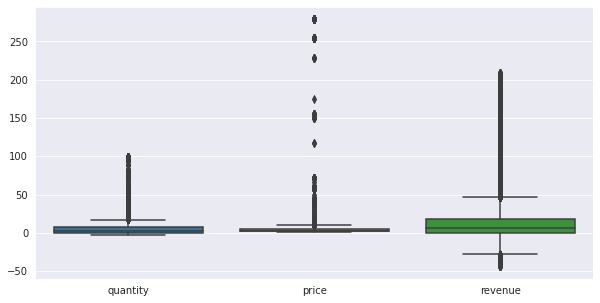

```python
plt.figure(figsize=(10, 5))
sns.boxplot(purchases[['quantity', 'price', 'revenue']]);
```

Часть выбросов присутствует, однако эти значения были опеределены как допустимые.

Также при обзоре данных было замечено, что некоторые `item_id` не относятся непосредственно к товарам, а являются сервисными.  
Их также следует исключить из анализа.

```python
service_items = []

for index in range(len(purchases)):
    if purchases['item_id'][index].isalpha() == True:
        if purchases['item_id'][index] not in service_items:
            service_items.append(purchases['item_id'][index])

service_items
```

```
['DOT', 'POST', 'M', 'DCGSSBOY', 'DCGSSGIRL', 'm']
```

```python
len(purchases.query('item_id in @service_items'))
```

```
422
```

```python
purchases = purchases.query('item_id not in @service_items')
```

Выбросы и другие искажающие данные значения удалены.  
Потери данных при этом не превысили 5%.

## Исследовательский алализ

Следующим этапом анализа является проверка значимых метрик, выявление закономерностей и формулирование первичных выводов об эффективности работы магазинов, значимости исследуемых бизнес-показателей и выдвижение гипотез, способствующих развитию сети.

Поскольку в датасете запись о каждой покупке разбита на несколько строк, соответствующих различным товарам в чеке, а в анализе покупка будет являться единым исследуемым элементом, данные аггрегируются по полю `purchase_id`.  
Далее работа будет вестись с аггрегированным датасетом.

```python
checks = \
purchases.groupby(by=['customer_id',
                      'loyalty',
                      'shop_id',
                      'purchase_date',
                      'purchase_id'],
                  as_index=False).agg({'item_id':'nunique',
                                      'quantity':'sum',
                                      'price':'mean',
                                      'revenue':'sum'}
                                     )
```

```python
checks = checks.rename(columns={'item_id':'unique_items',
                                'quantity':'total_items',
                                'price':'mean_item_price'
                               }
                      )
```

```python
checks[['mean_item_price', 'revenue']] = round(checks[['mean_item_price', 'revenue']], 2)
checks['purchase_date'] = pd.to_datetime(checks['purchase_date'])

checks['purchase_month'] = checks['purchase_date'].dt.strftime("%Y-%m")
```

```python
checks.head()
```

|  | customer_id | loyalty | shop_id | purchase_date | purchase_id | unique_items | total_items | mean_item_price | revenue | purchase_month |
| --- | --- | --- | --- | --- | --- | --- | --- | --- | --- | --- |
| 0 | 0 | 0 | Shop 0 | 2016-12-01 | 536544 | 514 | 626 | 3.47 | 1598.86 | 2016-12 |
| 1 | 0 | 0 | Shop 0 | 2016-12-01 | 536546 | 1 | 0 | 1.05 | 0.00 | 2016-12 |
| 2 | 0 | 0 | Shop 0 | 2016-12-01 | 536547 | 1 | 0 | 1.27 | 0.00 | 2016-12 |
| 3 | 0 | 0 | Shop 0 | 2016-12-01 | 536553 | 1 | 2 | 0.62 | 1.25 | 2016-12 |
| 4 | 0 | 0 | Shop 0 | 2016-12-01 | 536555 | 2 | 0 | 1.58 | 0.00 | 2016-12 |

Датасет "checks":

- `customer_id` — id клиента;
- `loyalty` — участвует ли покупатель в программе лояльности;
- `shop_id` — id магазина;
- `purchase_date` — дата покупки;
- `purchase_id` — id покупки;
- `unique_items` — количество уникальных товаров в покупке;
- `total_items` — общее количество товаров в покупке;
- `mean_item_price` — средняя стоимость одного товара;
- `revenue` — стоимость покупки;
- `purchase_month` — дата покупки в формате ГГГГ-ММ.

### Выручка торговых точек

```python
round(checks['revenue'].sum(),2)
```

```
1482575.15
```

```python
checks['purchase_date'].min()
```

```
Timestamp('2016-12-01 00:00:00')
```

```python
checks['purchase_date'].max()
```

```
Timestamp('2017-02-28 00:00:00')
```

Общая выручка сети за исследуемый период (с 1 декабря 2016г. по 28 февраля 2017г.) составила около 1,5 млн у.е.

#### Динамика выручки

```python
dayly_revenue = checks.pivot_table(index = 'purchase_date',
                                   values = 'revenue',
                                   aggfunc = 'sum'
                                  )
dayly_revenue["revenue_cum"] = dayly_revenue["revenue"].cumsum()
```

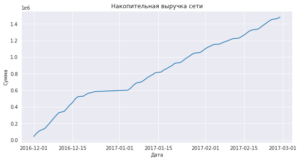

```python
plt.figure(figsize=(10, 5))

sns.lineplot(dayly_revenue['revenue_cum'])

plt.title('Накопительная выручка сети')
plt.ylabel('Сумма')
plt.xlabel('Дата');
```

На протяжении всего исследуемого периода, сеть показывает стабильный рост выручки.  
Также заметно снижение покупательской активности во второй половине декабря и первых числах января

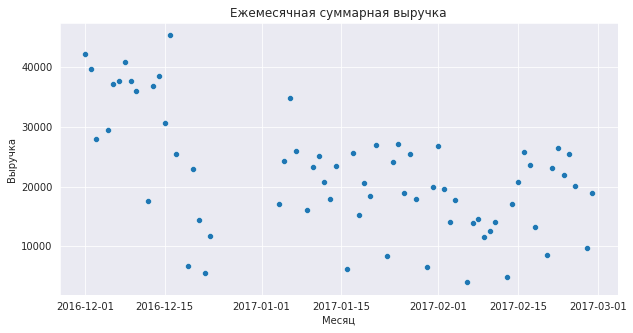

```python
daily_revenue = checks.groupby('purchase_date')['revenue'].sum()

plt.figure(figsize=(10, 5))

sns.scatterplot(y=daily_revenue,
                x=daily_revenue.index
               )

plt.title('Ежемесячная суммарная выручка')
plt.ylabel('Выручка')
plt.xlabel('Месяц');
```

Среднее ежедневное количество заказов в декабне выше, чем после нового года.

#### Сравнение торговых точек

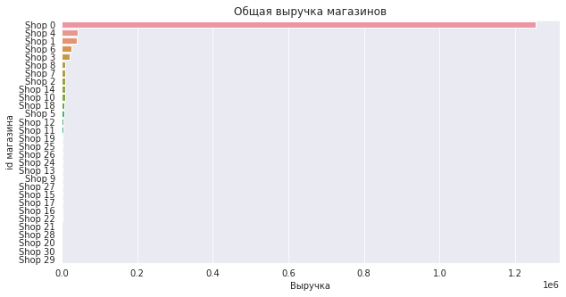

```python
total_revenue = checks.groupby('shop_id')['revenue'].sum().sort_values(ascending=False)

plt.figure(figsize=(10, 5))

sns.barplot(x=total_revenue,
            y=total_revenue.index,
            order=checks.groupby('shop_id')['revenue'].sum().sort_values(ascending=False).index
           )

plt.title('Общая выручка магазинов')
plt.ylabel('id магазина')
plt.xlabel('Выручка');
```

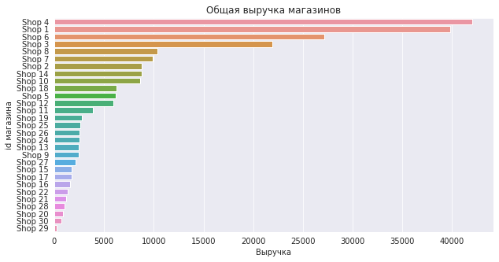

```python
plt.figure(figsize=(10, 5))

sns.barplot(x=total_revenue[1:],
            y=total_revenue[1:].index
           )

plt.title('Общая выручка магазинов')
plt.ylabel('id магазина')
plt.xlabel('Выручка');
```

Среди остальных магазинов также есть 4 точки, выручка которых заметно выше остальных.  
Это `Shop 1`, `Shop 3`, `Shop 4` и `Shop 6`.

Также следует сравнить полученные результаты с количеством покупок.

### Количество покупок

```python
checks['purchase_id'].nunique()
```

```
4144
```

#### Динамика изменения количества покупок

```python
dayly_purchases = checks.pivot_table(index = 'purchase_date',
                                   values = 'purchase_id',
                                   aggfunc = 'nunique'
                                  )
dayly_purchases.columns = ['purchase_count']
dayly_purchases["purchase_cum"] = dayly_purchases["purchase_count"].cumsum()
```

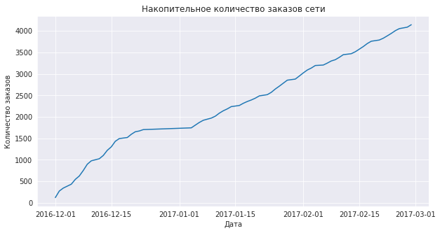

```python
plt.figure(figsize=(10, 5))

sns.lineplot(dayly_purchases['purchase_cum'])

plt.title('Накопительное количество заказов сети')
plt.ylabel('Количество заказов')
plt.xlabel('Дата');
```

График количества покупок практически идентичен графику выручки.

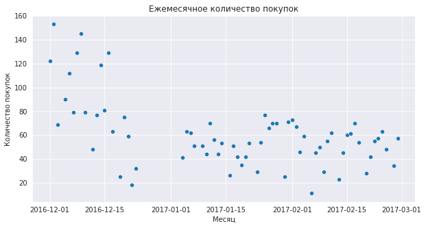

```python
daily_purchases = checks.groupby('purchase_date')['purchase_id'].nunique()

plt.figure(figsize=(10, 5))

sns.scatterplot(y=daily_purchases,
                x=daily_purchases.index
               )

plt.title('Ежемесячное количество покупок')
plt.ylabel('Количество покупок')
plt.xlabel('Месяц');
```

Ежедневное число покупок также было выше в декабре.

#### Сравнение торговых точек

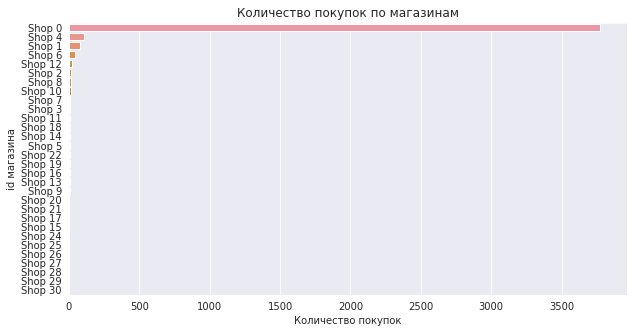

```python
shops_purchases = checks.groupby('shop_id')['purchase_id'].nunique().sort_values(ascending=False)

plt.figure(figsize=(10, 5))

sns.barplot(x=shops_purchases,
            y=shops_purchases.index,
           )

plt.title('Количество покупок по магазинам')
plt.ylabel('id магазина')
plt.xlabel('Количество покупок');
```

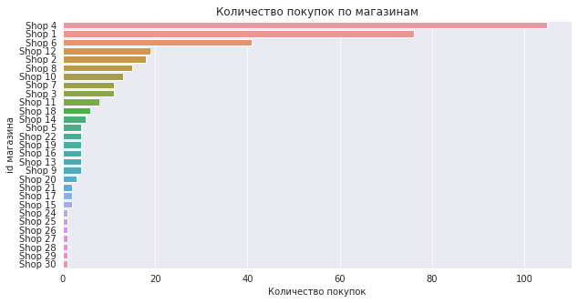

```python
plt.figure(figsize=(10, 5))

sns.barplot(x=shops_purchases[1:],
            y=shops_purchases[1:].index,
           )

plt.title('Количество покупок по магазинам')
plt.ylabel('id магазина')
plt.xlabel('Количество покупок');
```

### Количество уникальных клиентов

```python
checks['customer_id'].nunique()
```

```
1676
```

```python
len(checks[checks['customer_id'] == 0])
```

```
471
```

Всего за 3 месяца поступили заказы от почти 1700 клиентов, а также почти 500 не зарегистрированных в системе покупателей.

#### Динамика изменения количества покупателей

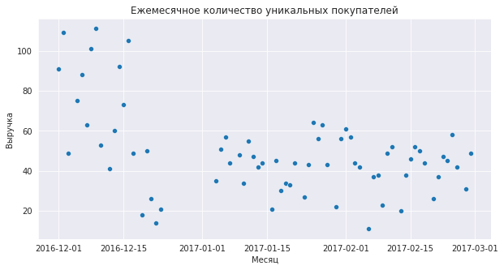

```python
daily_clients = checks.groupby('purchase_date')['customer_id'].nunique()

plt.figure(figsize=(10, 5))

sns.scatterplot(y=daily_clients,
                x=daily_clients.index
               )

plt.title('Ежемесячное количество уникальных покупателей')
plt.ylabel('Выручка')
plt.xlabel('Месяц');
```

Динамика количества уникальных клиентов, также как и выручка, показывает наибольшую активность в декабре.

#### Сравнение торговых точек

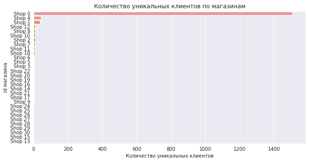

```python
shops_clients = checks.groupby('shop_id')['customer_id'].nunique().sort_values(ascending=False)

plt.figure(figsize=(10, 5))

sns.barplot(x=shops_clients,
            y=shops_clients.index
           )

plt.title('Количество уникальных клиентов по магазинам')
plt.ylabel('id магазина')
plt.xlabel('Количество уникальных клиентов');
```

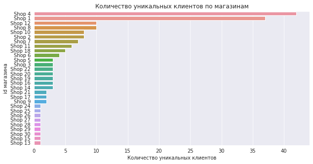

```python
plt.figure(figsize=(10, 5))

sns.barplot(x=shops_clients[1:],
            y=shops_clients[1:].index,
           )

plt.title('Количество уникальных клиентов по магазинам')
plt.ylabel('id магазина')
plt.xlabel('Количество уникальных клиентов');
```

Также практически все клиенты относятся к магазину `Shop 0`. `Shop 1` и `Shop 4` имеют наибольшее число покупателей среди остальных магазинов.

Важно отметить, что во всех остальных магазинах за 3 месяца совершили покупки не более 10 человек!  
Следует далее проверить количество покупок в этих магазинах, чтобы учесть незарегистрированных покупателей.

### Средний чек

#### Средняя сумма покупки

```python
round(checks['revenue'].mean(), 2)
```

```
357.76
```

```python
round(checks['revenue'].median(), 2)
```

```
212.14
```

Выше приведены значения средней и медианной стоимости покупок. Их отличие примерно в 1.5 раза обусловлено наличием крупных покупок.

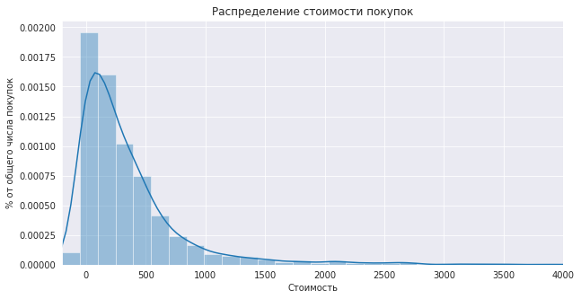

```python
plt.figure(figsize=(10, 5))

sns.distplot(checks['revenue'])
plt.xlim(checks['revenue'].min(), 4000)

plt.title('Распределение стоимости покупок')
plt.ylabel('% от общего числа покупок')
plt.xlabel('Стоимость');
```

#### Динамика изменения среднего чека

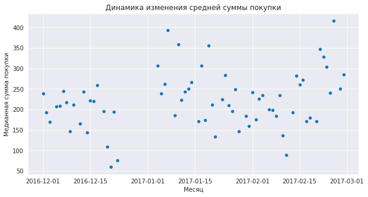

```python
daily_avg_bill = checks.groupby('purchase_date')['revenue'].median()

plt.figure(figsize=(10, 5))

sns.scatterplot(y=daily_avg_bill,
                x=daily_avg_bill.index
               )

plt.title('Динамика изменения средней суммы покупки')
plt.ylabel('Медианная сумма покупки')
plt.xlabel('Месяц');
```

В отличие от выручки и количества покупок, средняя стоимость покупки незначительно растет.

Это может быть связано с предновогодними распродажами, поскольку количество покупок выше, в то время как средний чек меньше

#### Количество товаров в чеке

```python
round(checks['total_items'].mean(), 2)
```

```
131.75
```

```python
checks['total_items'].median()
```

```
72.0
```

Среднее и медианное количество товаров в покупке также отличаются ввиду наличия объемных заказов.

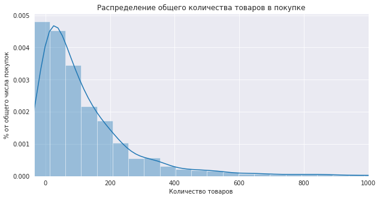

```python
plt.figure(figsize=(10, 5))

sns.distplot(checks['total_items'])
plt.xlim(checks['total_items'].min(),1000)

plt.title('Распределение общего количества товаров в покупке')
plt.ylabel('% от общего числа покупок')
plt.xlabel('Количество товаров');
```

Покупатели крайне редко приобретают более 200 единиц за одну покупку.  
Скорее всего остальные заказы оптовые, либо состоят из небольших расходных материалов.

```python
round(checks['unique_items'].mean(), 2)
```

```
23.89
```

```python
checks['unique_items'].median()
```

```
12.0
```

Среднее и медианное количество уникальных товаров также отличаются.

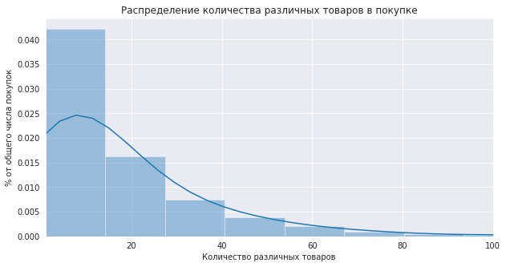

```python
plt.figure(figsize=(10, 5))

sns.distplot(checks['unique_items'])
plt.xlim(checks['unique_items'].min(),100)

plt.title('Распределение количества различных товаров в покупке')
plt.ylabel('% от общего числа покупок')
plt.xlabel('Количество различных товаров');
```

Количество наименований в покупке обычно не превышает 20 единиц.

#### Средняя стоимость одного товара в чеке

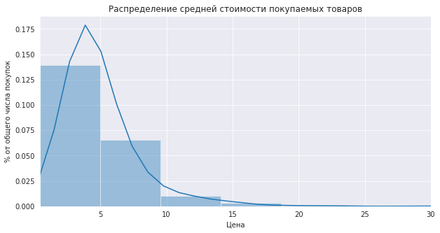

```python
plt.figure(figsize=(10, 5))

sns.distplot(checks['mean_item_price'])
plt.xlim(checks['mean_item_price'].min(),30)

plt.title('Распределение средней стоимости покупаемых товаров')
plt.ylabel('% от общего числа покупок')
plt.xlabel('Цена');
```

Чаще всего покупаются товары ценой до 10 у.е.

#### Сравнение торговых точек

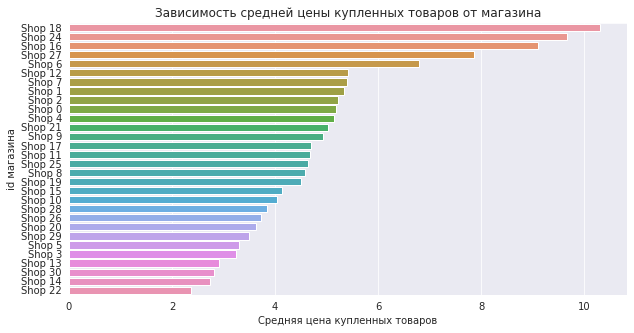

```python
shops_avg_bill = checks.groupby('shop_id')['mean_item_price'].mean().sort_values(ascending=False)

plt.figure(figsize=(10, 5))

sns.barplot(x=shops_avg_bill,
            y=shops_avg_bill.index
           )

plt.title('Зависимость средней цены купленных товаров от магазина')
plt.ylabel('id магазина')
plt.xlabel('Средняя цена купленных товаров');
```

### Количество возвратов

```python
orders = checks.query('total_items > 0')
returns = checks.query('total_items < 0')
```

```python
print(f'''Общее количество покупок: {orders['purchase_id'].nunique()}
Количество возвратов: {returns['purchase_id'].nunique()}
Доля возвратов: {returns["purchase_id"].nunique() / orders["purchase_id"].nunique():.2%}''')
```

```
Общее количество покупок: 3512
Количество возвратов: 486
Доля возвратов: 13.84%
```

#### Сравнение торговых точек

```python
shop_orders = orders.groupby('shop_id')['purchase_id'].nunique().sort_values(ascending=False)
shop_returns = returns.groupby('shop_id')['purchase_id'].nunique().sort_values(ascending=False)

shop_orders = pd.concat([shop_orders, shop_returns], axis= 1)
shop_orders.columns = ['orders_count', 'returns_count']
shop_orders['return_ratio'] = round(shop_orders['returns_count'] / shop_orders['orders_count'], 3)
```

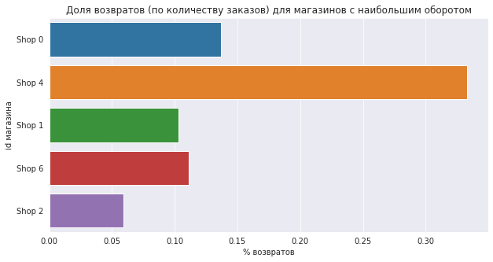

```python
plt.figure(figsize=(10, 5))

sns.barplot(x=shop_orders.head()['return_ratio'],
            y=shop_orders.head().index
           )

plt.title('Доля возвратов (по количеству заказов) для магазинов с наибольшим оборотом')
plt.ylabel('id магазина')
plt.xlabel('% возвратов');
```

В оценке доли возвратов от числа покупок были проанализированы магазины с наибольшим общим количеством заказов.  
Среди них выделяется магазин `Shop 4`, в котором доля возвратов достигает 35%.

### Количество "пустых" заказов

```python
zero_checks = checks.query('total_items == 0')
```

```python
zero_checks['purchase_id'].nunique()
```

```
146
```

```python
print(f'{zero_checks["purchase_id"].nunique() / checks["purchase_id"].nunique():.2%}')
```

```
3.52%
```

В датасете содержатся заказы с нулевой суммой покупки.  
Возможно покупатели отказывались от покупки на кассе магазина или при оформлении онлайн-заказа.  
Тем не менее, их доля достаточно низкая, менее 4%.

#### Сравнение торговых точек

```python
shop_checks = checks.groupby('shop_id')['purchase_id'].nunique().sort_values(ascending=False)
shop_zero_checks = zero_checks.groupby('shop_id')['purchase_id'].nunique().sort_values(ascending=False)

shop_checks = pd.concat([shop_checks, shop_zero_checks], axis= 1)
shop_checks.columns = ['checks_count', 'zero_checks_count']
shop_checks['return_ratio'] = round(shop_checks['zero_checks_count'] / shop_checks['checks_count'], 3)
```

```python
shop_checks.head(5)
```

| shop_id | checks_count | zero_checks_count | return_ratio |
| --- | --- | --- | --- |
| Shop 0 | 3776 | 142.0 | 0.038 |
| Shop 4 | 105 | 1.0 | 0.010 |
| Shop 1 | 76 | 1.0 | 0.013 |
| Shop 6 | 41 | 1.0 | 0.024 |
| Shop 12 | 19 | NaN | NaN |

Практически все "нулевые" заказы приходятся на магазин `Shop 0`, что подтверждает гипотезу о том, что покупатели не заканчивали оформление онлайн-заказов.

### Удержание клиентов

Поскольку покупки носят нерегулярный характер, под термином "удержание клиентов" подразумевается общее количество заказов, совершенных одним покупателем.

```python
customer_order_count = checks.query('customer_id > 0').pivot_table(index=['shop_id',
                                                                          'customer_id'
                                                                         ],
                                                                   values='purchase_id',
                                                                   aggfunc='nunique'
                                                                  )
customer_order_count.reset_index(inplace=True)
customer_order_count.rename(columns={'purchase_id': 'order_count'}, inplace=True)
```

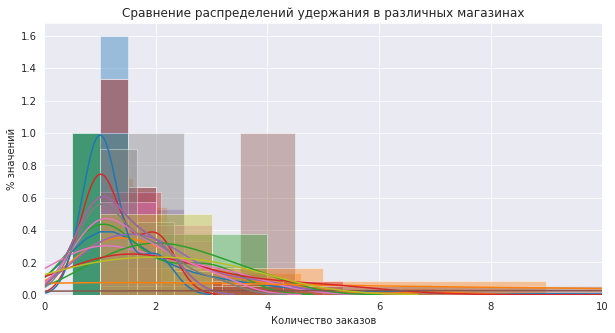

```python
plt.figure(figsize=(10, 5))
for i in customer_order_count['shop_id'].unique():
    plt.xlim(0, 10)

    sns.distplot(customer_order_count.query('shop_id == @i')['order_count'])

    plt.title('Сравнение распределений удержания в различных магазинах')
    plt.ylabel('% значений')
    plt.xlabel('Количество заказов');
```

Клиенты обычно совершили одну или две покупки в течение исследуемого периода.

#### Сравнение торговых точек

```python
shop_mean_customer_order_count = \
customer_order_count.groupby('shop_id')['order_count'].agg('mean').sort_values(ascending=False)
```

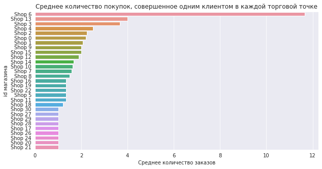

```python
plt.figure(figsize=(10, 5))

sns.barplot(x=shop_mean_customer_order_count,
            y=shop_mean_customer_order_count.index
           )

plt.title('Среднее количество покупок, совершенное одним клиентом в каждой торговой точке')
plt.ylabel('id магазина')
plt.xlabel('Среднее количество заказов');
```

### Ассортимент товаров

```python
purchases['item_id'].nunique()
```

```
3021
```

Всего в сети представлено более 3000 товаров, практически все из них можно приобрести в магазине `Shop 0`

```python
shop_items = purchases.groupby('shop_id')['item_id'].nunique().sort_values(ascending=False)
```

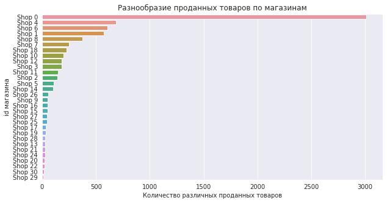

```python
plt.figure(figsize=(10, 5))

sns.barplot(x=shop_items,
            y=shop_items.index
           )

plt.title('Разнообразие проданных товаров по магазинам')
plt.ylabel('id магазина')
plt.xlabel('Количество различных проданных товаров');
```

Магазины, выше продемонстрировавшие наибольшие значения выручки, количества покупок и клиентов также имеют наибольший ассортимент.

### Отличие стоимости товаров в различных магазинах

```python
shop_item_price = purchases.groupby('shop_id')['price'].median().sort_values(ascending=False)
```

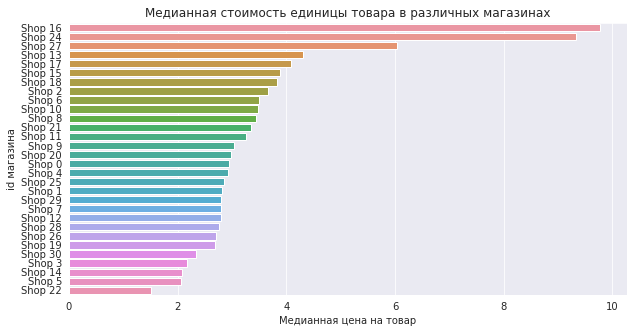

```python
plt.figure(figsize=(10, 5))

sns.barplot(x=shop_item_price,
            y=shop_item_price.index
           )

plt.title('Медианная стоимость единицы товара в различных магазинах')
plt.ylabel('id магазина')
plt.xlabel('Медианная цена на товар');
```

### Выводы

В результате исследовательского анализа было выявлено следующее:

1. В течение исследуемого периода клиенты совершили более 4000 покупок. *(Общая выручка сети составила около 1,5млн. у.е.)*
2. Магазин `Shop 0` вносит наибольший вклад в работу сети. *(В нем было совершено более 90% покупок.)*
3. Более половины магазинов имеют крайне низкую активность. *(Менее 20 заказов и менее 10 клиентов)*
4. Магазины с наибольшим ассортиментом товаров показывают наибольшую эффективность.
5. Магазин `Shop 4` имеет высокую долю возвратов.
6. Около 20% покупателей не зарегистрированы в базе данных.
7. Каждый клиент совершил в среднем 2 покупки.

## Статистический анализ

С целью развития сети и повышения эффективности работы были сформулированы статистические гипотезы для проверки.  
Исследуется покупательская активность, а также значимость бизнес-метрик.

Поскольку количество магазинов велико, а количество покупок у большинства из них небольшое, проверка гипотез проводится среди топ-5 магазинов по суммарной выручке.

```python
top_shops = checks.groupby('shop_id')['revenue'].sum().sort_values(ascending = False).head()

top_shops
```

```
shop_id
Shop 0    1255195.62
Shop 4      42050.75
Shop 1      39830.46
Shop 6      27111.53
Shop 3      21922.07
Name: revenue, dtype: float64
```

```python
top_shops_data = checks.query('shop_id in @top_shops.index')
```

### Проверка гипотезы H0 "Средний чек одинаковый во всех магазинах"

Первая проверяемая гипотеза заключается в сравнении средней суммы покупки между различными магазинами сети

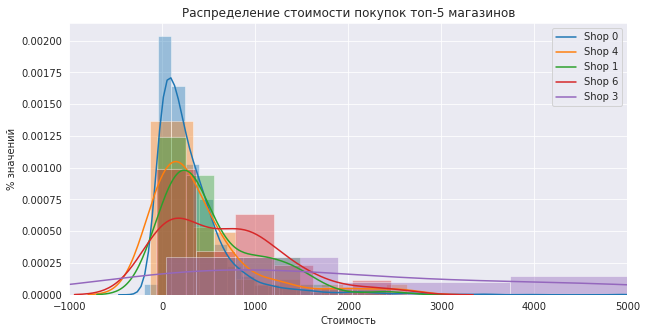

```python
plt.figure(figsize=(10, 5))
for i in top_shops.index:
    sns.distplot(top_shops_data.query('shop_id == @i')['revenue'])
    plt.legend(labels=top_shops.index)
    plt.xlim(-1000, 5000)

    plt.title('Распределение стоимости покупок топ-5 магазинов')
    plt.ylabel('% значений')
    plt.xlabel('Стоимость');
```

Исходя из визуальных данных, средние выборок близки между собой, однако форма распределений отличается.

Для статистических тестов нулевая и альтернативная гипотеза сформулированы следующим образом:

**H0:** Во всех магазинах средний чек одинаковый.  
**H1:** Средний чек в различных магазинах отличается.

Поскольку магазин `Shop 0` имеет 90% заказов, при проверке сравнивается его средний чек со средними чеками других магазинов.

```python
sample_1 = checks.query('shop_id == @top_shops.index[0]')['revenue']
sample_2 = top_shops_data.query('shop_id == @top_shops.index[0]')['revenue']

alpha = .05
test_counter = 0

for i in top_shops.index[1:]:
    test_counter += 1

alpha_multi = alpha / (test_counter + 1)

for i in top_shops.index[1:]:
    sample_2  = top_shops_data.query('shop_id == @i')['revenue']
    results = st.ttest_ind(sample_1, sample_2)

    print(f'''
Сравнение средних чеков магазинов `Shop 0` и `{i}`:
p-значение:, {results.pvalue:.3}''')
    if results.pvalue < alpha_multi:
        print("Отвергаем нулевую гипотезу, средний чек отличается")
    else:
        print("Гипотеза подтверждена, средний чек одинаковый")
    print ('---------------------------------------------------------------------')
```

```
Сравнение средних чеков магазинов `Shop 0` и `Shop 4`:
p-значение:, 0.145
Гипотеза подтверждена, средний чек одинаковый
---------------------------------------------------------------------

Сравнение средних чеков магазинов `Shop 0` и `Shop 1`:
p-значение:, 0.000433
Отвергаем нулевую гипотезу, средний чек отличается
---------------------------------------------------------------------

Сравнение средних чеков магазинов `Shop 0` и `Shop 6`:
p-значение:, 8.8e-06
Отвергаем нулевую гипотезу, средний чек отличается
---------------------------------------------------------------------

Сравнение средних чеков магазинов `Shop 0` и `Shop 3`:
p-значение:, 4.02e-30
Отвергаем нулевую гипотезу, средний чек отличается
---------------------------------------------------------------------
```

Из четырех проверок только одна показала, что средний чек одинаковый.  
Следовательно, гипотеза H0 `Средний чек во всех магазинах одинаковый` отвергнута.

### Проверка гипотезы H0 "Клиенты совершают больше покупок в конце года, чем в другое время"

Также статистически проверяется предположение, что перед новым годом наблюдается повышенный спрос, вследствие чего количество покупок повышается.

```python
ny_checks = checks[checks['purchase_date'].dt.month == 12]

ny_orders_count = ny_checks.groupby('purchase_date')['purchase_id'].agg('nunique')
```

```python
not_ny_checks = checks[checks['purchase_date'].dt.month != 12]

not_ny_orders_count = not_ny_checks.groupby('purchase_date')['purchase_id'].agg('nunique')
```

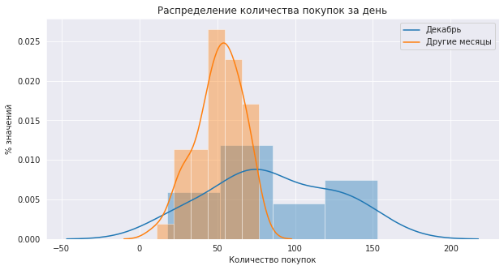

```python
plt.figure(figsize=(10, 5))
for df in [ny_orders_count, not_ny_orders_count]:

    sns.distplot(df)
    plt.legend(labels=['Декабрь', 'Другие месяцы'])

    plt.title('Распределение количества покупок за день')
    plt.ylabel('% значений')
    plt.xlabel('Количество покупок');
```

Данный график, как и накопительный график общего количества заказов показывает отличие средних значений в декабре.  
Тем не менее, следует проверить эти данные статистически.

Для проверки сформулированы следующие нулевая и альтернативная гипотезы:

**H0:** Среднее ежедневное количество покупок в декабре не отличается от среднего в другие месяцы.  
**H1:** Среднее ежедневное количество покупок в декабре выше, чем в другие месяцы.

Следовательно, мы сможем утверждать, что количество заказов в декабре выше ожидаемого, если нулевая гипотеза будет отвергнута при достаточном уровне статистической значимости.

Поскольку распределение заказов в декабре отлично от нормального (вероятно, ввиду недостаточного размера выборки), в ходе проверки будет использовано сравнение распределения со ожидаемым значением.  
В качестве ожидаемой величины выбрано среднее ежедневное количество заказов в остальное время.

```python
sample_1 = not_ny_orders_count.mean()

round(sample_1,2)
```

```
50.83
```

```python
sample_2 = ny_orders_count

alpha = .05

results = st.ttest_1samp(sample_2, sample_1)

print(f'''Сравнение количества заказов в декабре и в другое время:
p-значение: {results.pvalue / 2:.3}''')

if (results.pvalue / 2 < alpha) and (sample_2.mean() > sample_1):
    print("Отвергаем нулевую гипотезу, среднее количество заказов в конце года выше")
else:
    print('''Нулевая гипотеза не отвергается,
среднее количество заказов в конце года не отличается от среднего в другое время''')
```

```
Сравнение количества заказов в декабре и в другое время:
p-значение: 0.000467
Отвергаем нулевую гипотезу, среднее количество заказов в конце года выше
```

В конце года покупок больше, чем в другое время, что позволяет выдвинуть предположение о наличии повышенного спроса в данный период.

### Выводы

В ходе проверки статистических гипотез было определено, что средние суммы покупок среди магазинов сети отличаются, а покупательская активность в конце года повышается.

## Итоги исследования

**В результате исследования были выявлены существенные различия в работе магазинов сети:**

1. Общая выручка сети за 3 месяца составила около 1,5млн. у.е.
2. Магазин `Shop 0` приносит около 85% от всей выручки.
3. Значительная часть магазинов совершили крайне малое количество продаж.

**Также были обнаружены определенные закономерности в покупательской активности:**

1. Чаще всего покупают товары, стоимостью около 5 у.е.
2. Один клиент совершает в среднем 2 покупки.
3. Около 15% товаров возвращают в магазин.
4. Около 20% покупателей не зарегистрированы в базе данных.

### Рекомендации

**Финансы**

1. С целью повышения прибыльности бизнеса следует в первую очередь ориентироваться на работу магазина `Shop 0`, важно регулярно отслеживать его работу.
2. Возможно следует провести аудит работы остальных магазинов сети, поскольку ввиду низкой выручки их работа может приносить убыток (для анализа этого необходимо дополнить исследование информацией о затратах).

**Маркетинг**  
В ходе исследования был выявлен ряд корреляций, которые могут способствовать развитию сети: